# Lake Okeechobee Recovery Ops Forecast

Updated: 2025-07-10 10:26:00 EDT

## Purpose

This webpage/report is intended to share potential scenario forecasts associated with Lake Okeechobee Recovery Operations in the late-2024 to mid-2025 time period.

## Framework

This forecasts are based on a hydrological modeling framework for lake water level management using a simple water balance equation (below).

$$\frac{\Delta V}{\Delta t} = I_t -Q_t +
A_t\times (P_t - E_t)$$

Where

- $V_t$ (ac-ft) and $A_t$ (acres) are volume/storage and area based on the stage-volume-area relationships specific to Lake Okeechobee based on recent bathymetry
- $P_t$ ($ft \; d^{-1}$) and $E_t$ ($ft \; d^{-1}$) are precipitation and evapotranspiration
  - Based on historic data (last 10 water years) spatially averaged from monitoring locations (see Data Sources, below).
- $I_t$ ($ac\mbox{-}ft \; d^{-1}$) is inflow discharges to the lake based on historic discharges
- $Q_t$ ($ac\mbox{-}ft \; d^{-1}$) is outflow discharges from the lake based on a combination of historic discharges and pulse releases depending on the scenario.

### Stage-Volume-Area

Using the most recent 15 meter spatial resolution bathymetric data of Lake Okeechobee (2009) we can estimate/derive the Stage-Volume-Area relationship using to calculate/estimate the lake area and storage volume of the lake at a given stage elevation.

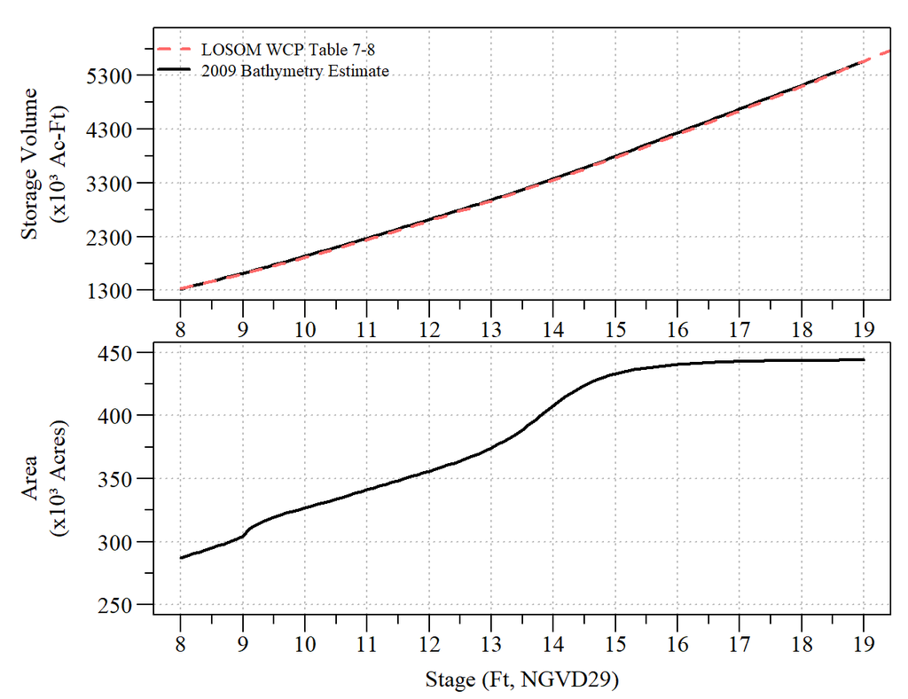

Stage-Volume-Area relationships for Lake Okeechobee

## Scenarios

To evaluate the change in lake stage several scenarios were considered. Each scenario is intended to understand how the lake stage could change given changes to lake inflows and outflows. When using historic data (i.e. ET, inflow, and outflow discharges to EAA) period of record median values were used.

[output not shown]

Upper and lower bounds of scenario forecasts were calculated using historically observed data based on management objectives during wetter and drier conditions, respectively. Using daily observed discharge, rainfall and ET values between May 2015 to current, the upper (wetter) bounds used the 10th percentile discharge volume to the EAA (plus amount dictated by each respective scenario), 90th percentile for lake inflows, 10th percentile for ET and 90th percentile for rainfall to estimate the change in storage. Conversely for drier conditions (lower bounds) the 90th percentile discharge volume to the EAA, 10th percentile for lake inflows, 90th percentile for ET and 10th percentile for rainfall to estimate the change in storage.

## Results

At the start of the lake recovery period (Dec 07), lake Okeechobee stage was at 15.58 Ft NGVD29. Yesterday (Jul, 09 2025), lake Okeechobee stage was at 11.49 Ft NGVD29. As of yesterday, the 14-day moving average for inflows north and outflows east, west and south were 1073, 1974, 37 and 224cfs.

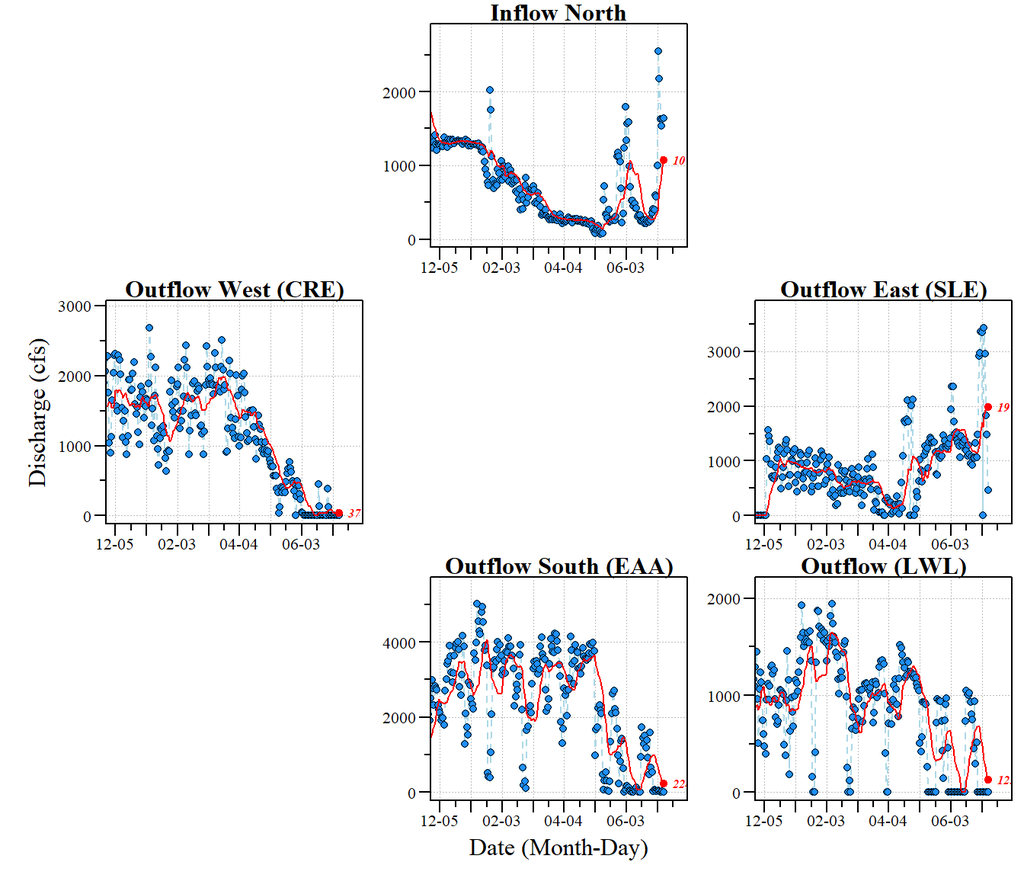

Daily and 14-day moving average discharge volumes for inflows north and outflows east, west and south

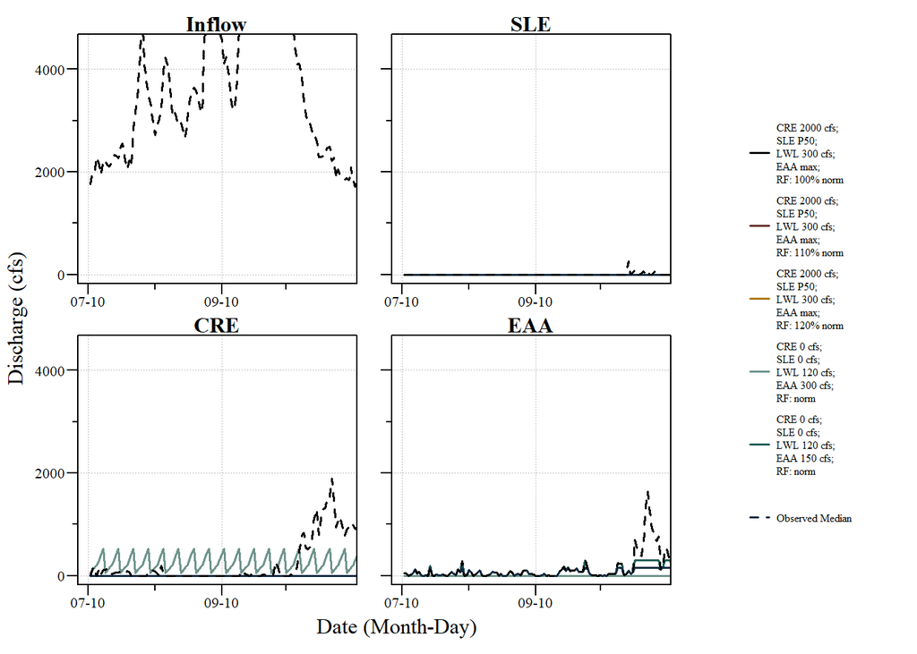

Scenario discharge volumes for inflow, CRE, SLE and EAA relative to day-of-year median discharge volume.

### Scenario 1

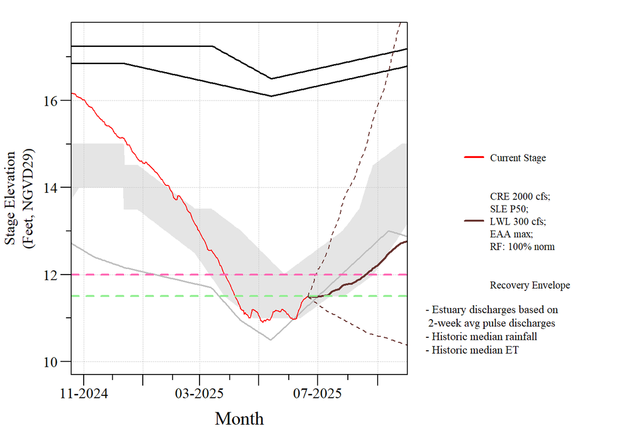

Lake Okeechobee Stage forecast under scenario # 1 (wetter (upper line) and drier (lower line) conditions).

### Scenario 2

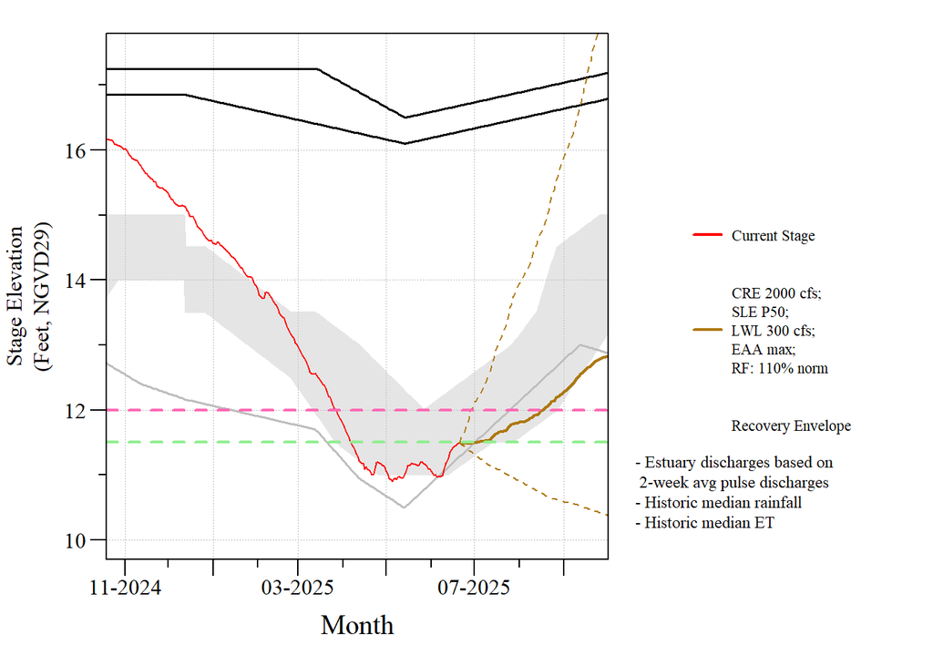

Lake Okeechobee Stage forecast under scenario # 2 (wetter (upper line) and drier (lower line) conditions).

### Scenario 3

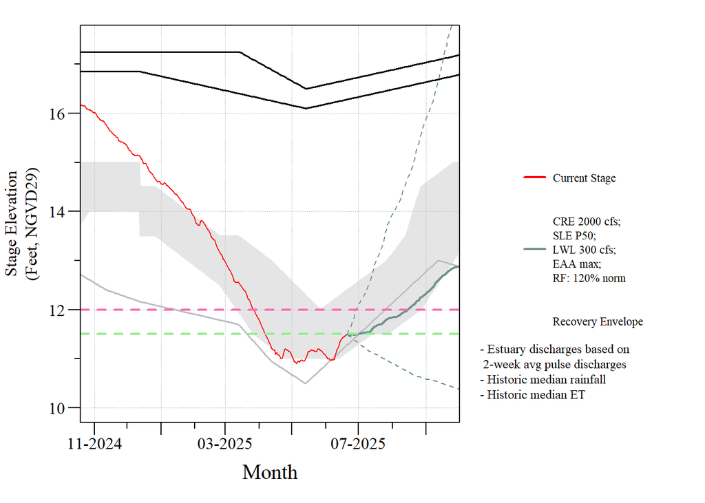

Lake Okeechobee Stage forecast under scenario # 3 (wetter (upper line) and drier (lower line) conditions).

### Scenario 4

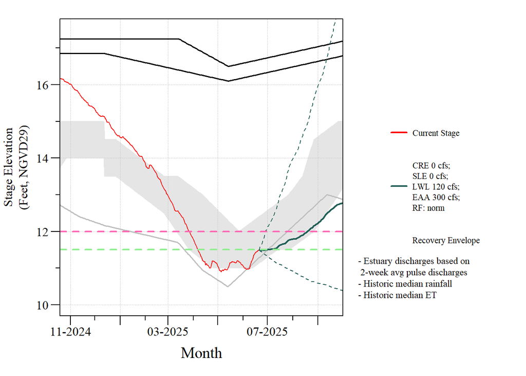

Lake Okeechobee Stage forecast under scenario # 4 (wetter (upper line) and drier (lower line) conditions).

### Scenario 5

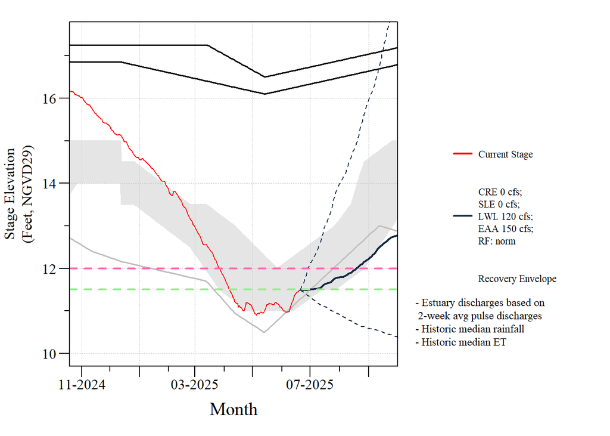

Lake Okeechobee Stage forecast under scenario # 5 (wetter (upper line) and drier (lower line) conditions).

### Base

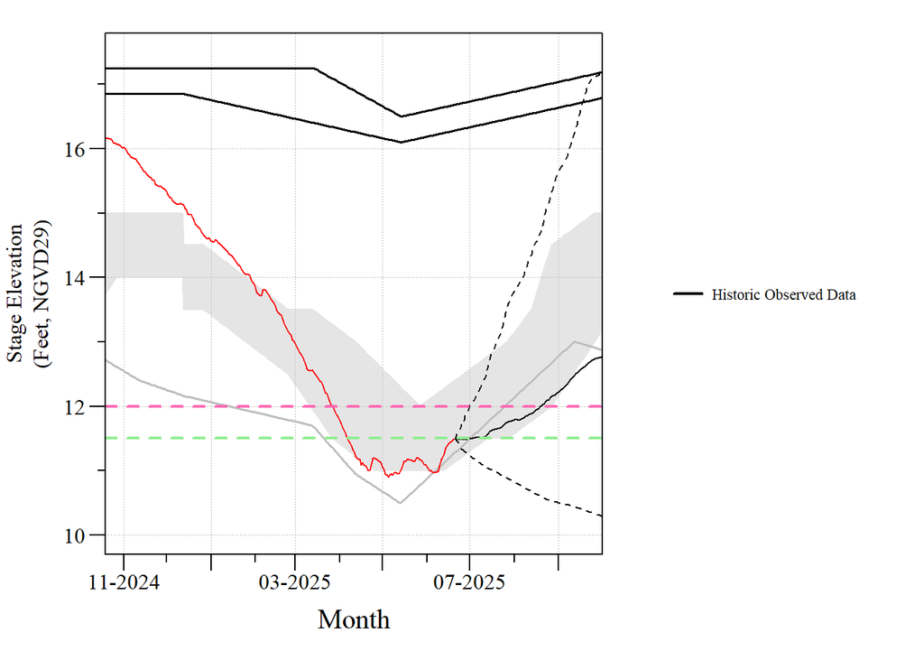

Base lake Okeechobee Stage forecast using historical data (wetter (upper line) and drier (lower line) conditions).

### All Scenarios

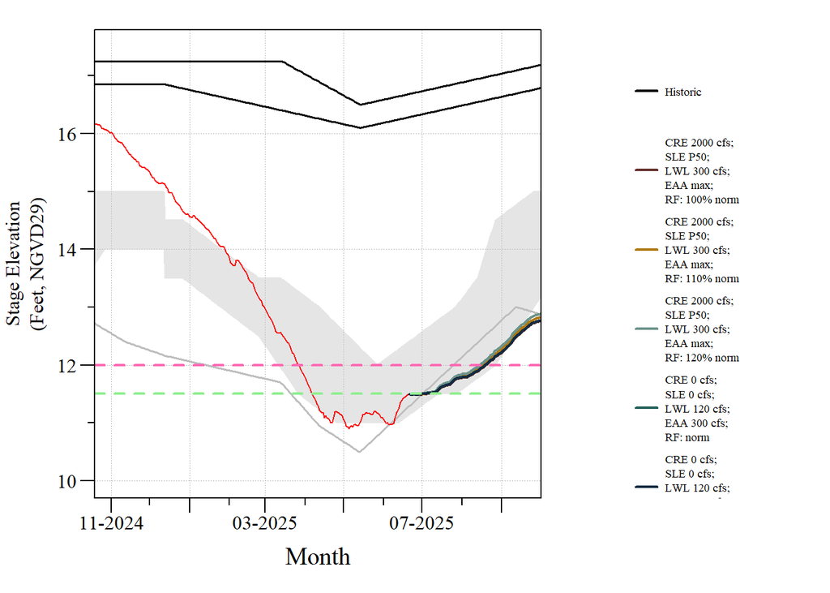

Lake Okeechobee Stage forecast under all scenarios.

## Data Sources

All data were retrieved from SFWMD DBhydro between 01 May 2015 and 10 Jul 2025 from the following DBKeys.

| DBKEY | STATION | GROUP | SITE | DATA.TYPE | FREQ | STAT | RECORDER | AGENCY | BASIN |
| --- | --- | --- | --- | --- | --- | --- | --- | --- | --- |
| 06832 | L OKEE | L OKEE | L OKEE | STG29 | DA | MEAN | COMP | COE | L OKEE |
| 00268 | L OKEE | L OKEE | L OKEE | STG29 | DA | MEAN | ???? | USGS | L OKEE |
| WZ688 | LAKEOKEE | LAKEOKEE | L OKEE | ETPI | DA | SUM | DRV | WMD | L OKEE |
| UT743 | L006 | L006 | L006 | ETPI | DA | SUM | CR10 | WMD | L OKEE |
| UT748 | LZ40 | LZ40 | LZ40 | ETPI | DA | SUM | CR10 | WMD | L OKEE |
| TW080 | BELLE GL | BELLE GL | BELLW | ETPI | DA | SUM | CR10 | WMD | S-2_6_7 |
| UA627 | CFSW | CFSW | CFSW | ETPI | DA | SUM | CR10 | WMD | S-4 |
| 16021 | L001 | L001 | L001 | RAIN | DA | SUM | CR10 | WMD | L OKEE |
| 13081 | LZ40 | LZ40 | LZ40 | RAIN | DA | SUM | CR10 | WMD | L OKEE |
| 12524 | L006 | L006 | L006 | RAIN | DA | SUM | CR10 | WMD | L OKEE |
| 12515 | L005 | L OKE.W | L005 | RAIN | DA | SUM | CR10 | WMD | L OKEE |
| AL760 | S65EX1_S | S65EX1_S | S65EX1 | FLOW | DA | MEAN | DRV | WMD | S-65E |
| 91656 | S65E_S | S65E | S65E | FLOW | DA | MEAN | DRV | WMD | L OKEE |
| 91687 | S84_S | S84 | S84 | FLOW | DA | MEAN | DRV | WMD | C41AS |
| 91686 | S84X_S | S84X_S | S84X | FLOW | DA | MEAN | DRV | WMD | C41AS |
| 91675 | S72_S | S72 | S72 | FLOW | DA | MEAN | DRV | WMD | C40 |
| 91668 | S71_S | S71 | S71 | FLOW | DA | MEAN | DRV | WMD | C41S |
| 91513 | S354_S | S354 | S354 | FLOW | DA | MEAN | DRV | WMD | L OKEE |
| 91508 | S351_S | S351 | S351 | FLOW | DA | MEAN | DRV | WMD | L OKEE |
| 91510 | S352_S | S352 | S352 | FLOW | DA | MEAN | DRV | WMD | L OKEE |
| 02855 | L8.441 | L8.441 | L8.441 | FLOW | DA | MEAN |  | USGS | L8 |
| DJ235 | S77_S | S77 | S77 | FLOW | DA | MEAN |  | COE | L OKEE |
| DJ239 | S308_S | S308 | S308 | FLOW | DA | MEAN |  | COE | L OKEE |
| 65409 | S271_C | S271_C | S271 | FLOW | DA | MEAN | TELE | COE | L OKEE |
| 91510 | S352_S | S352 | S352 | FLOW | DA | MEAN | DRV | WMD | L OKEE |